# R Notebook

This example is based on https://www.kaggle.com/sindhuee/r-caret-example and https://www.kaggle.com/cesartrevisan/using-xgboost-to-predict-breast-cancer using the same terminology (for the most part from Section 6) with some revisions by Linda Boyle and John Lee

## Load packages

`r`r library(caret) library(tidyverse) library(skimr)

## Read data in subdirectory called Data

`r`r cancer.df<- read.csv(‘./Data/cancer.csv’) #head(cancer.df) #view only the first few lines of data #str(cancer.df) #review the structure of the data skim(cancer.df)

```
Skim summary statistics
 n obs: 569
 n variables: 32

── Variable type:factor ──────────────────────────────────────────────────────────────────────────────────────────────────────────
  variable missing complete   n n_unique            top_counts ordered
 diagnosis       0      569 569        2 B: 357, M: 212, NA: 0   FALSE

── Variable type:integer ─────────────────────────────────────────────────────────────────────────────────────────────────────────
 variable missing complete   n  mean      sd   p0    p25    p50     p75    p100     hist
       id       0      569 569 3e+07 1.3e+08 8670 869218 906024 8813129 9.1e+08 ▇▁▁▁▁▁▁▁

── Variable type:numeric ─────────────────────────────────────────────────────────────────────────────────────────────────────────
                variable missing complete   n     mean       sd        p0      p25      p50       p75     p100     hist
               area_mean       0      569 569 654.89   351.91   143.5     420.3    551.1     782.7    2501     ▅▇▂▂▁▁▁▁
                 area_se       0      569 569  40.34    45.49     6.8      17.85    24.53     45.19    542.2   ▇▁▁▁▁▁▁▁
              area_worst       0      569 569 880.58   569.36   185.2     515.3    686.5    1084      4254     ▇▅▂▁▁▁▁▁
        compactness_mean       0      569 569   0.1      0.053    0.019     0.065    0.093     0.13      0.35  ▅▇▆▃▁▁▁▁
          compactness_se       0      569 569   0.025    0.018    0.0023    0.013    0.02      0.032     0.14  ▇▆▂▁▁▁▁▁
       compactness_worst       0      569 569   0.25     0.16     0.027     0.15     0.21      0.34      1.06  ▆▇▅▂▁▁▁▁
     concave.points_mean       0      569 569   0.049    0.039    0         0.02     0.034     0.074     0.2   ▇▆▃▃▁▁▁▁
       concave.points_se       0      569 569   0.012    0.0062   0         0.0076   0.011     0.015     0.053 ▃▇▅▁▁▁▁▁
    concave.points_worst       0      569 569   0.11     0.066    0         0.065    0.1       0.16      0.29  ▃▇▇▅▅▃▂▁
          concavity_mean       0      569 569   0.089    0.08     0         0.03     0.062     0.13      0.43  ▇▃▂▂▁▁▁▁
            concavity_se       0      569 569   0.032    0.03     0         0.015    0.026     0.042     0.4   ▇▂▁▁▁▁▁▁
         concavity_worst       0      569 569   0.27     0.21     0         0.11     0.23      0.38      1.25  ▇▆▅▂▁▁▁▁
  fractal_dimension_mean       0      569 569   0.063    0.0071   0.05      0.058    0.062     0.066     0.097 ▃▇▆▂▁▁▁▁
    fractal_dimension_se       0      569 569   0.0038   0.0026   0.00089   0.0022   0.0032    0.0046    0.03  ▇▂▁▁▁▁▁▁
 fractal_dimension_worst       0      569 569   0.084    0.018    0.055     0.071    0.08      0.092     0.21  ▆▇▃▁▁▁▁▁
          perimeter_mean       0      569 569  91.97    24.3     43.79     75.17    86.24    104.1     188.5   ▂▇▇▃▂▁▁▁
            perimeter_se       0      569 569   2.87     2.02     0.76      1.61     2.29      3.36     21.98  ▇▂▁▁▁▁▁▁
         perimeter_worst       0      569 569 107.26    33.6     50.41     84.11    97.66    125.4     251.2   ▂▇▃▂▂▁▁▁
             radius_mean       0      569 569  14.13     3.52     6.98     11.7     13.37     15.78     28.11  ▁▆▇▃▂▁▁▁
               radius_se       0      569 569   0.41     0.28     0.11      0.23     0.32      0.48      2.87  ▇▂▁▁▁▁▁▁
            radius_worst       0      569 569  16.27     4.83     7.93     13.01    14.97     18.79     36.04  ▂▇▅▂▂▁▁▁
         smoothness_mean       0      569 569   0.096    0.014    0.053     0.086    0.096     0.11      0.16  ▁▂▇▇▃▁▁▁
           smoothness_se       0      569 569   0.007    0.003    0.0017    0.0052   0.0064    0.0081    0.031 ▅▇▂▁▁▁▁▁
        smoothness_worst       0      569 569   0.13     0.023    0.071     0.12     0.13      0.15      0.22  ▁▃▆▇▃▁▁▁
           symmetry_mean       0      569 569   0.18     0.027    0.11      0.16     0.18      0.2       0.3   ▁▃▇▇▂▁▁▁
             symmetry_se       0      569 569   0.021    0.0083   0.0079    0.015    0.019     0.023     0.079 ▇▇▃▁▁▁▁▁
          symmetry_worst       0      569 569   0.29     0.062    0.16      0.25     0.28      0.32      0.66  ▁▇▆▂▁▁▁▁
            texture_mean       0      569 569  19.29     4.3      9.71     16.17    18.84     21.8      39.28  ▂▆▇▅▂▁▁▁
              texture_se       0      569 569   1.22     0.55     0.36      0.83     1.11      1.47      4.88  ▆▇▃▁▁▁▁▁
           texture_worst       0      569 569  25.68     6.15    12.02     21.08    25.41     29.72     49.54  ▂▆▇▆▅▁▁▁
```

# Clean and prepare data

`r`r cancer.df<- subset(cancer.df,select=-c(id)) #select everything but the first column cancer.df$diagnosis<-factor(cancer.df$diagnosis) #make diagnosis a factor

# Visualize data

`r`r table(cancer.df$diagnosis) #B=benign, M=malignant

```
  B   M
357 212
```

`r`r featurePlot(x = cancer.df[, 2:11], y = cancer.df$diagnosis, plot = , scales=list(x=list(relation=),y=list(relation=)), auto.key=list(columns=2), #add a key at the top layout = c(3, 4))

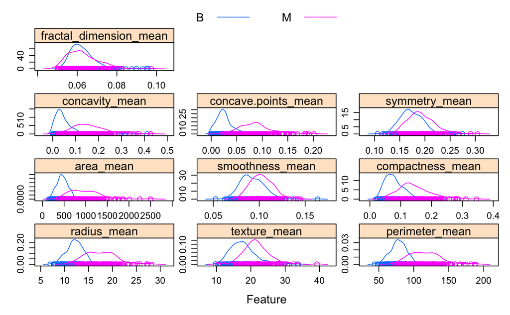

# partition data into training and testing

`r`r #From the Slides inTrain = createDataPartition(cancer.df$diagnosis, p = 3/4, list = FALSE) trainDescr = cancer.df[inTrain, -(1:2)] # All but class variable testDescr = cancer.df[-inTrain, -(1:2)] trainClass = cancer.df$diagnosis[inTrain] testClass = cancer.df$diagnosis[-inTrain] cancer.df$diagnosis %>% table() %>% prop.table() %>% round(2)*100 #proportion in entire table

```
.
 B  M
63 37
```

`r`r trainClass %>% table() %>% prop.table() %>% round(2)*100 #proportion in training

```
.
 B  M
63 37
```

`r`r testClass %>% table() %>% prop.table() %>% round(2)*100 #proportion in testing

```
.
 B  M
63 37
```

# Preprocessing of data

`r`r xTrans = preProcess(trainDescr, method = c(, )) trainScaled = predict(xTrans, trainDescr) testScaled = predict(xTrans, testDescr)

# Set a 10 fold cross validation, repeated 3x to be used in the forthcoming models

For more on n-cross validation and repeated cross validation, see http://appliedpredictivemodeling.com/blog/2014/11/27/vpuig01pqbklmi72b8lcl3ij5hj2qm

`r`r fitControl<-trainControl( method =, #repeated cross validation number=10, #10 fold repeats=3, #3 times; to gain precision classProbs =TRUE, #to obtain class predictions savePredictions = ‘final’, summaryFunction=twoClassSummary )

# logistic regression

`r`r glm.fit<-train(x = trainScaled, y = trainClass, method=‘glm’, family=binomial(), metric=‘ROC’, #set model for binary logit trControl=fitControl)

[output not shown]

`r`r glm.fit

```
Generalized Linear Model

427 samples
 29 predictor
  2 classes: 'B', 'M'

No pre-processing
Resampling: Cross-Validated (10 fold, repeated 3 times)
Summary of sample sizes: 384, 384, 384, 385, 384, 384, ...
Resampling results:

  ROC        Sens       Spec
  0.9351829  0.9377493  0.9186111
```

# svm

`r`r svm.fit

```
Support Vector Machines with Linear Kernel

427 samples
 29 predictor
  2 classes: 'B', 'M'

No pre-processing
Resampling: Cross-Validated (10 fold, repeated 3 times)
Summary of sample sizes: 384, 384, 384, 385, 384, 385, ...
Resampling results:

  ROC        Sens       Spec
  0.9946836  0.9838082  0.9451389

Tuning parameter 'C' was held constant at a value of 1
```

# xgboost

`r`r xgb.fit = train(x = trainScaled, y = trainClass, method = , metric = , tuneLength = 3, # Depends on number of parameters in algorithm trControl = fitControl, scaled = TRUE) xgb.fit

```
eXtreme Gradient Boosting

427 samples
 29 predictor
  2 classes: 'B', 'M'

No pre-processing
Resampling: Cross-Validated (10 fold, repeated 3 times)
Summary of sample sizes: 384, 384, 384, 384, 384, 385, ...
Resampling results across tuning parameters:

  eta  max_depth  colsample_bytree  subsample  nrounds  ROC        Sens       Spec
  0.3  1          0.6               0.50        50      0.9859894  0.9665242  0.9288889
  0.3  1          0.6               0.50       100      0.9866170  0.9627255  0.9309722
  0.3  1          0.6               0.50       150      0.9868374  0.9663818  0.9225000
  0.3  1          0.6               0.75        50      0.9853818  0.9665242  0.9227778
  0.3  1          0.6               0.75       100      0.9877760  0.9676638  0.9206944
  0.3  1          0.6               0.75       150      0.9881669  0.9664292  0.9205556
  0.3  1          0.6               1.00        50      0.9852944  0.9614910  0.9206944
  0.3  1          0.6               1.00       100      0.9871557  0.9626781  0.9205556
  0.3  1          0.6               1.00       150      0.9873079  0.9652422  0.9205556
  0.3  1          0.8               0.50        50      0.9884321  0.9615385  0.9248611
  0.3  1          0.8               0.50       100      0.9893610  0.9701330  0.9268056
  0.3  1          0.8               0.50       150      0.9901193  0.9713675  0.9287500
  0.3  1          0.8               0.75        50      0.9892715  0.9690408  0.9183333
  0.3  1          0.8               0.75       100      0.9909036  0.9727445  0.9162500
  0.3  1          0.8               0.75       150      0.9918244  0.9776828  0.9183333
  0.3  1          0.8               1.00        50      0.9870616  0.9665717  0.9163889
  0.3  1          0.8               1.00       100      0.9892300  0.9702754  0.9143056
  0.3  1          0.8               1.00       150      0.9896239  0.9751662  0.9226389
  0.3  2          0.6               0.50        50      0.9855619  0.9615385  0.9227778
  0.3  2          0.6               0.50       100      0.9866370  0.9664767  0.9309722
  0.3  2          0.6               0.50       150      0.9861533  0.9664292  0.9184722
  0.3  2          0.6               0.75        50      0.9866965  0.9615859  0.9206944
  0.3  2          0.6               0.75       100      0.9876136  0.9664767  0.9248611
  0.3  2          0.6               0.75       150      0.9878413  0.9664292  0.9269444
  0.3  2          0.6               1.00        50      0.9862306  0.9651947  0.9206944
  0.3  2          0.6               1.00       100      0.9873160  0.9651472  0.9248611
  0.3  2          0.6               1.00       150      0.9876246  0.9664292  0.9311111
  0.3  2          0.8               0.50        50      0.9894464  0.9690408  0.9226389
```

[output cut: 71 more lines]

```
  0.4  3          0.8               0.50        50      0.9899960  0.9652896  0.9225000
  0.4  3          0.8               0.50       100      0.9905302  0.9702279  0.9266667
  0.4  3          0.8               0.50       150      0.9906897  0.9764008  0.9245833
  0.4  3          0.8               0.75        50      0.9901062  0.9739316  0.9225000
  0.4  3          0.8               0.75       100      0.9902598  0.9738841  0.9287500
  0.4  3          0.8               0.75       150      0.9906507  0.9751187  0.9308333
  0.4  3          0.8               1.00        50      0.9895940  0.9726971  0.9225000
  0.4  3          0.8               1.00       100      0.9898204  0.9689934  0.9183333
  0.4  3          0.8               1.00       150      0.9902164  0.9689934  0.9204167

Tuning parameter 'gamma' was held constant at a value of 0
Tuning parameter 'min_child_weight' was held constant at a value of 1
ROC was used to select the optimal model using the largest value.
The final values used for the model were nrounds = 150, max_depth = 2, eta = 0.4, gamma = 0, colsample_bytree =
 0.8, min_child_weight = 1 and subsample = 0.5.
```

# feature importance

`r`r varImp(glm.fit)

```
glm variable importance

  only 20 most important variables shown (out of 29)
```

`r`r varImp(xgb.fit)

```
xgbTree variable importance

  only 20 most important variables shown (out of 29)
```

[output not shown]

[output cut: 10 more lines]

|  | Overall |
| --- | --- |
| perimeter_worst | 100.0000000 |
| radius_worst | 38.1633075 |
| concave.points_mean | 28.6641165 |
| texture_mean | 14.4304762 |
| texture_worst | 10.8489294 |
| concavity_mean | 8.1510690 |
| area_worst | 6.4860690 |
| area_mean | 5.4043033 |
| symmetry_se | 4.8643734 |
| fractal_dimension_se | 4.8101931 |

[output cut: 10 more lines]

# predict on test dataset

`r`r glm.fit_pred<-predict(glm.fit,testScaled) xgb.fit_pred<-predict(xgb.fit,testScaled)

# results

`r`r confusionMatrix(xgb.fit_pred,testClass)

```
Confusion Matrix and Statistics

          Reference
Prediction  B  M
         B 89  5
         M  0 48

               Accuracy : 0.9648
                 95% CI : (0.9197, 0.9885)
    No Information Rate : 0.6268
    P-Value [Acc > NIR] : < 2e-16

                  Kappa : 0.9233
 Mcnemar's Test P-Value : 0.07364

            Sensitivity : 1.0000
            Specificity : 0.9057
         Pos Pred Value : 0.9468
         Neg Pred Value : 1.0000
             Prevalence : 0.6268
         Detection Rate : 0.6268
   Detection Prevalence : 0.6620
      Balanced Accuracy : 0.9528

       'Positive' Class : B
```

`r`r confusionMatrix(xgb.fit_pred,testClass)

```
Confusion Matrix and Statistics

          Reference
Prediction  B  M
         B 89  5
         M  0 48

               Accuracy : 0.9648
                 95% CI : (0.9197, 0.9885)
    No Information Rate : 0.6268
    P-Value [Acc > NIR] : < 2e-16

                  Kappa : 0.9233
 Mcnemar's Test P-Value : 0.07364

            Sensitivity : 1.0000
            Specificity : 0.9057
         Pos Pred Value : 0.9468
         Neg Pred Value : 1.0000
             Prevalence : 0.6268
         Detection Rate : 0.6268
   Detection Prevalence : 0.6620
      Balanced Accuracy : 0.9528

       'Positive' Class : B
```

# compare models

`r`r mod.resamps = resamples(list(glm = glm.fit, svm. = svm.fit, xgb = xgb.fit)) bwplot(mod.resamps, metric=)

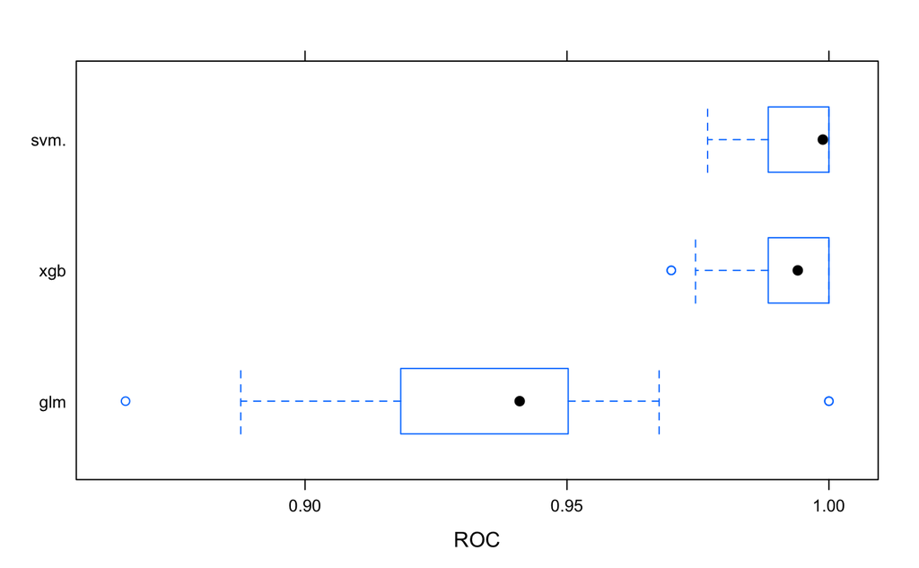